# Power Plants in the World

### *Update date: January, 2022*

- [Data source](http://datasets.wri.org/dataset/globalpowerplantdatabase)

## World Power Plant Data Visualized

From the Global Database of Power Plants created by WRI and their partners, I will analyze the energy production capacity and primary fuel information between different countries and individual plants.

```python
import pandas as pd
import numpy as np
import matplotlib.pyplot as plt
import geopandas as gpd

data = pd.read_csv('global_power_plant_database.csv', header=0, low_memory=False)
pd.set_option('display.max_columns', 50)
data.head(2)
```

|  | country | country_long | name | gppd_idnr | capacity_mw | latitude | longitude | primary_fuel | other_fuel1 | other_fuel2 | other_fuel3 | commissioning_year | owner | source | url | geolocation_source | wepp_id | year_of_capacity_data | generation_gwh_2013 | generation_gwh_2014 | generation_gwh_2015 | generation_gwh_2016 | generation_gwh_2017 | generation_gwh_2018 | generation_gwh_2019 | generation_data_source | estimated_generation_gwh_2013 | estimated_generation_gwh_2014 | estimated_generation_gwh_2015 | … |
| --- | --- | --- | --- | --- | --- | --- | --- | --- | --- | --- | --- | --- | --- | --- | --- | --- | --- | --- | --- | --- | --- | --- | --- | --- | --- | --- | --- | --- | --- | --- |
| 0 | AFG | Afghanistan | Kajaki Hydroelectric Power Plant Afghanistan | GEODB0040538 | 33.0 | 32.322 | 65.119 | Hydro | NaN | NaN | NaN | NaN | NaN | GEODB | http://globalenergyobservatory.org | GEODB | 1009793 | 2017.0 | NaN | NaN | NaN | NaN | NaN | NaN | NaN | NaN | 123.77 | 162.90 | 97.39 | … |
| 1 | AFG | Afghanistan | Kandahar DOG | WKS0070144 | 10.0 | 31.670 | 65.795 | Solar | NaN | NaN | NaN | NaN | NaN | Wiki-Solar | https://www.wiki-solar.org | Wiki-Solar | NaN | NaN | NaN | NaN | NaN | NaN | NaN | NaN | NaN | NaN | 18.43 | 17.48 | 18.25 | … |

I want to compare the sizes of different power plants. There is information about the plant capacity, as well as the actual and estimated energy production (estimation method is described in the documentation of the database). However, very few power plants have actually publically disclosed the generation data, so I will use the capacity data for now. The amount of the NaN values in different columns confirms this.

```python
na_counts = 1 - pd.DataFrame(data.iloc[:,[4,18,19,20,21,22,23,24,26,27,28,29,30]].isna().sum()/len(data))
na_counts = na_counts.rename(columns = {0:'percentage of defined values'})
na_counts
```

|  | percentage of defined values |
| --- | --- |
| capacity_mw | 1.000000 |
| generation_gwh_2013 | 0.183679 |
| generation_gwh_2014 | 0.206835 |
| generation_gwh_2015 | 0.234801 |
| generation_gwh_2016 | 0.261736 |
| generation_gwh_2017 | 0.271926 |
| generation_gwh_2018 | 0.275847 |
| generation_gwh_2019 | 0.276477 |
| estimated_generation_gwh_2013 | 0.461415 |
| estimated_generation_gwh_2014 | 0.472378 |
| estimated_generation_gwh_2015 | 0.488035 |
| estimated_generation_gwh_2016 | 0.502920 |
| estimated_generation_gwh_2017 | 0.948534 |

Indeed, all power plants have capacity information but only about 25% include data about actual electricity generation. The estimation model, on the other hand, has been applied to 95% of the plants.

I'll compare the plants based on their primary fuel, as well as the capacity data. First questions:

- How many power plants use each primary fuel?
- What is the total capacity (MW) of all primary fuels globally?

```python
byFuel = data.groupby(data['primary_fuel']).agg({'primary_fuel':'count', 'capacity_mw':'sum'})
byFuel.rename(columns={'primary_fuel':'plants'}, inplace=True)
byFuel.sort_values('plants', ascending=True, inplace=True)
byFuel
```

| primary_fuel | plants | capacity_mw |
| --- | --- | --- |
| Wave and Tidal | 10 | 5.522000e+02 |
| Petcoke | 12 | 2.424577e+03 |
| Cogeneration | 41 | 4.048000e+03 |
| Other | 43 | 3.612860e+03 |
| Storage | 135 | 1.712300e+03 |
| Geothermal | 189 | 1.268775e+04 |
| Nuclear | 195 | 4.079118e+05 |
| Waste | 1068 | 1.474871e+04 |
| Biomass | 1430 | 3.428130e+04 |
| Oil | 2320 | 2.618787e+05 |
| Coal | 2330 | 1.965541e+06 |
| Gas | 3998 | 1.493051e+06 |
| Wind | 5344 | 2.630537e+05 |
| Hydro | 7156 | 1.053160e+06 |
| Solar | 10665 | 1.883123e+05 |

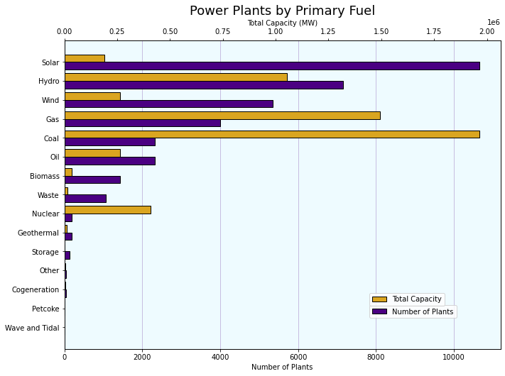

```python
fig, ax = plt.subplots(figsize=(11,8))
yAxis = np.arange(0, len(byFuel.index))
barHeight = 0.4

ax.barh(y=yAxis-barHeight/2, width=byFuel['plants'], height=barHeight,
        color='indigo', label='Number of Plants', zorder=3, edgecolor='black')
ax.set_xlabel('Number of Plants')
ax.set_facecolor('#00BFFF11')

ax2 = ax.twiny()

ax2.barh(y=yAxis+barHeight/2, width=byFuel['capacity_mw'], height=barHeight,
         color='goldenrod', label='Total Capacity', zorder=3, edgecolor='black')
ax2.set_xlabel('Total Capacity (MW)')

plt.yticks(yAxis, byFuel.index)

plt.title('Power Plants by Primary Fuel', fontsize=18)

ax.legend(loc=(0.7,0.1))
ax2.legend(loc=(0.7,0.14))

ax.grid(axis='x', zorder=1, color='indigo', alpha=0.3)

plt.show()
```

Some remarks from the results:

- Solar, hydro and wind power are the most used forms of energy measured in the number of plants
- However, solar and wind energy are only the 7th and 5th largest energy forms in combined energy capacity
- The most efficient fuels (comparing the average power plant capacity) seem to be nuclear, coal and gas

Moving on, I'm adding another grouper, based on whether the primary fuel is renewable or not. I'll use it to calculate which countries can produce the most renewable energy compared to non-renewable energy.

```python
data['renewable'] = np.where(data['primary_fuel'].isin(['Geothermal', 'Hydro', 'Solar', 'Wave and Tidal', 'Wind', 'Biomass', 'Waste']), 1, 0)
```

```python
renew = data.groupby(['country_long', 'renewable']).agg(total_capacity=('capacity_mw', sum))
renew = renew.reset_index()
renew
```

|  | country_long | renewable | total_capacity |
| --- | --- | --- | --- |
| 0 | Afghanistan | 0 | 42.000 |
| 1 | Afghanistan | 1 | 258.550 |
| 2 | Albania | 0 | 98.000 |
| 3 | Albania | 1 | 1431.000 |
| 4 | Algeria | 0 | 15179.000 |
| ... | ... | ... | ... |
| 300 | Yemen | 0 | 1045.000 |
| 301 | Zambia | 0 | 469.600 |
| 302 | Zambia | 1 | 2219.737 |
| 303 | Zimbabwe | 0 | 920.000 |
| 304 | Zimbabwe | 1 | 750.000 |

305 rows × 3 columns

```python
renew = renew.pivot(index='country_long', columns='renewable', values='total_capacity')
renew = renew.reset_index().rename_axis(None,axis='columns')
renew = renew.rename(columns={1.0:'renewable_mw', 0.0:'nonrenewable_mw'})
renew = renew.replace(np.NaN, 0)
renew['renewable_ratio'] = renew.renewable_mw / (renew.renewable_mw + renew.nonrenewable_mw)
renew.sort_values('renewable_ratio', ascending=False)
```

|  | country_long | nonrenewable_mw | renewable_mw | renewable_ratio |
| --- | --- | --- | --- | --- |
| 127 | Saint Lucia | 0.00 | 3.0 | 1.0 |
| 140 | Suriname | 0.00 | 5.0 | 1.0 |
| 102 | Mozambique | 0.00 | 2285.0 | 1.0 |
| 115 | Palestine | 0.00 | 7.6 | 1.0 |
| 49 | Ethiopia | 0.00 | 4023.9 | 1.0 |
| ... | ... | ... | ... | ... |
| 20 | Brunei Darussalam | 586.00 | 0.0 | 0.0 |
| 150 | Trinidad and Tobago | 2144.60 | 0.0 | 0.0 |
| 84 | Lebanon | 2070.30 | 0.0 | 0.0 |
| 87 | Libya | 6231.00 | 0.0 | 0.0 |
| 47 | Eritrea | 133.19 | 0.0 | 0.0 |

167 rows × 4 columns

I'll use geopandas to visualize this data.

```python
worldmap = gpd.read_file('https://d2ad6b4ur7yvpq.cloudfront.net/naturalearth-3.3.0/ne_50m_admin_0_sovereignty.geojson')
worldmap.rename(columns={'sovereignt':'country_long'}, inplace=True)
```

I'll do a quick comparison of the country names in the power plant data and in the geospatial data, spot countries with unmatching names and match these.

```python
set(worldmap.country_long) - set(renew.country_long)
```

```
{'Andorra',
 'Antigua and Barbuda',
 'Barbados',
 'Belize',
 'Brunei',
 'Chad',
 'Comoros',
 'Dominica',
 'East Timor',
 'Federated States of Micronesia',
 'Grenada',
 'Guinea Bissau',
 'Haiti',
 'Ivory Coast',
 'Kashmir',
 'Kiribati',
 'Liechtenstein',
 'Maldives',
 'Malta',
 'Marshall Islands',
 'Monaco',
 'Nauru',
 'Northern Cyprus',
 'Palau',
 'Republic of Congo',
 'Republic of Serbia',
 'Saint Kitts and Nevis',
 'Saint Vincent and the Grenadines',
 'Samoa',
 'San Marino',
 'Sao Tome and Principe',
 'Seychelles',
 'Solomon Islands',
 'Somalia',
 'Somaliland',
 'South Sudan',
 'Syria',
 'The Bahamas',
 'Tonga',
 'United Republic of Tanzania',
 'Vanuatu',
 'Vatican'}
```

```python
set(renew.country_long) - set(worldmap.country_long)
```

```
{'Brunei Darussalam',
 'Congo',
 'Cote DIvoire',
 'French Guiana',
 'Guinea-Bissau',
 'Palestine',
 'Serbia',
 'Syrian Arab Republic',
 'Tanzania'}
```

```python
worldmap.replace({'country_long' :
                  { 'Brunei':'Brunei Darussalam',
                   'Republic of Congo':'Congo',
                   'Ivory Coast':'Cote DIvoire',
                   'Guinea Bissau':'Guinea-Bissau',
                   'Republic of Serbia':'Serbia',
                   'Syria':'Syrian Arab Republic',
                   'United Republic of Tanzania':'Tanzania'
                  }}, inplace=True)

merged = pd.merge(worldmap, renew, on='country_long', how='left')
merged
```

|  | scalerank | labelrank | country_long | sov_a3 | adm0_dif | level | type | admin | adm0_a3 | geou_dif | geounit | gu_a3 | su_dif | subunit | su_a3 | brk_diff | name | name_long | brk_a3 | brk_name | brk_group | abbrev | postal | formal_en | formal_fr | ... | iso_a2 | iso_a3 | iso_n3 | … |
| --- | --- | --- | --- | --- | --- | --- | --- | --- | --- | --- | --- | --- | --- | --- | --- | --- | --- | --- | --- | --- | --- | --- | --- | --- | --- | --- | --- | --- | --- | --- |
| 0 | 1 | 3 | Afghanistan | AFG | 0 | 2 | Sovereign country | Afghanistan | AFG | 0 | Afghanistan | AFG | 0 | Afghanistan | AFG | 0 | Afghanistan | Afghanistan | AFG | Afghanistan | None | Afg. | AF | Islamic State of Afghanistan | None | ... | AF | AFG | 004 | … |
| 1 | 1 | 3 | Angola | AGO | 0 | 2 | Sovereign country | Angola | AGO | 0 | Angola | AGO | 0 | Angola | AGO | 0 | Angola | Angola | AGO | Angola | None | Ang. | AO | People's Republic of Angola | None | ... | AO | AGO | 024 | … |
| 2 | 1 | 6 | Albania | ALB | 0 | 2 | Sovereign country | Albania | ALB | 0 | Albania | ALB | 0 | Albania | ALB | 0 | Albania | Albania | ALB | Albania | None | Alb. | AL | Republic of Albania | None | ... | AL | ALB | 008 | … |
| 3 | 3 | 6 | Andorra | AND | 0 | 2 | Sovereign country | Andorra | AND | 0 | Andorra | AND | 0 | Andorra | AND | 0 | Andorra | Andorra | AND | Andorra | None | And. | AND | Principality of Andorra | None | ... | AD | AND | 020 | … |
| 4 | 1 | 4 | United Arab Emirates | ARE | 0 | 2 | Sovereign country | United Arab Emirates | ARE | 0 | United Arab Emirates | ARE | 0 | United Arab Emirates | ARE | 0 | United Arab Emirates | United Arab Emirates | ARE | United Arab Emirates | None | U.A.E. | AE | United Arab Emirates | None | ... | AE | ARE | 784 | … |
| ... | ... | ... | ... | ... | ... | ... | ... | ... | ... | ... | ... | ... | ... | ... | ... | ... | ... | ... | ... | ... | ... | ... | ... | ... | ... | ... | ... | ... | ... | … |
| 195 | 1 | 4 | Samoa | WSM | 0 | 2 | Sovereign country | Samoa | WSM | 0 | Samoa | WSM | 0 | Samoa | WSM | 0 | Samoa | Samoa | WSM | Samoa | None | Samoa | WS | Independent State of Samoa | None | ... | WS | WSM | 882 | … |
| 196 | 1 | 3 | Yemen | YEM | 0 | 2 | Sovereign country | Yemen | YEM | 0 | Yemen | YEM | 0 | Yemen | YEM | 0 | Yemen | Yemen | YEM | Yemen | None | Yem. | YE | Republic of Yemen | None | ... | YE | YEM | 887 | … |
| 197 | 1 | 2 | South Africa | ZAF | 0 | 2 | Sovereign country | South Africa | ZAF | 0 | South Africa | ZAF | 0 | South Africa | ZAF | 0 | South Africa | South Africa | ZAF | South Africa | None | S.Af. | ZA | Republic of South Africa | None | ... | ZA | ZAF | 710 | … |
| 198 | 1 | 3 | Zambia | ZMB | 0 | 2 | Sovereign country | Zambia | ZMB | 0 | Zambia | ZMB | 0 | Zambia | ZMB | 0 | Zambia | Zambia | ZMB | Zambia | None | Zambia | ZM | Republic of Zambia | None | ... | ZM | ZMB | 894 | … |
| 199 | 1 | 3 | Zimbabwe | ZWE | 0 | 2 | Sovereign country | Zimbabwe | ZWE | 0 | Zimbabwe | ZWE | 0 | Zimbabwe | ZWE | 0 | Zimbabwe | Zimbabwe | ZWE | Zimbabwe | None | Zimb. | ZW | Republic of Zimbabwe | None | ... | ZW | ZWE | 716 | … |

200 rows × 67 columns

I've merged the data and am ready to plot.

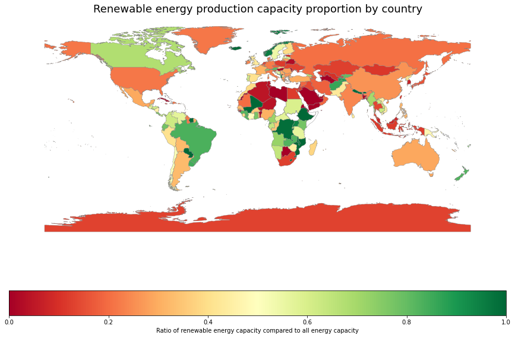

```python
merged.plot(column='renewable_ratio', cmap='RdYlGn', figsize=(15,10), legend=True,
            legend_kwds={'label':'Ratio of renewable energy capacity compared to all energy capacity', 'orientation':'horizontal'},
            edgecolor='grey', linewidth=0.4)

plt.axis('off')
plt.title('Renewable energy production capacity proportion by country', fontsize=18)
plt.show()
```

I will plot every power plant on a world map. The larger the circle, the larger the capacity of the plant. I'll also distinguish the plants by the renewable/non-renewable division I made.

```python
powerplantsGeo = gpd.GeoDataFrame(data, geometry=gpd.points_from_xy(data.longitude, data.latitude))
powerplantsRenewable = powerplantsGeo[powerplantsGeo['renewable'] == 1]
powerplantsNonRenewable = powerplantsGeo[powerplantsGeo['renewable'] == 0]
```

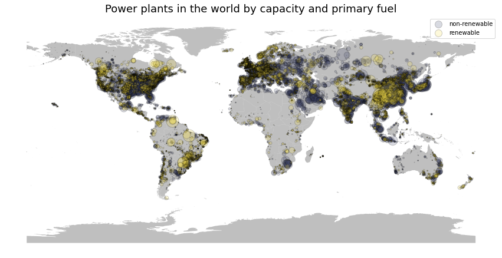

```python
from matplotlib.lines import Line2D

basemap = worldmap.plot(color='grey', alpha=0.5, figsize=(15,10))

powerplantsNonRenewable.plot(ax=basemap, figsize=(15,10), alpha=0.2, facecolor='#41476B',
                    markersize=powerplantsNonRenewable['capacity_mw']/20, edgecolor='black')

powerplantsRenewable.plot(ax=basemap, figsize=(15,10), alpha=0.2, facecolor='#F9E147',
                    markersize=powerplantsRenewable['capacity_mw']/20, edgecolor='black')

legend_elems = [Line2D([0],[0], c='w', markerfacecolor='#41476B', marker='o', markeredgecolor='black', markersize=12, alpha=0.2, label='non-renewable'),
               Line2D([0],[0], c='w', markerfacecolor='#F9E147', marker='o', markeredgecolor='black', markersize=12, alpha=0.2, label='renewable')]

plt.legend(handles=legend_elems)
plt.axis('off')
plt.title('Power plants in the world by capacity and primary fuel', fontsize=18)
plt.show()
```

I'll examine only Nordic power plants now

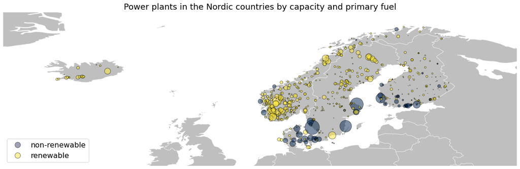

```python
powerplantsNordic = powerplantsGeo[powerplantsGeo['country_long'].isin(['Finland', 'Sweden', 'Norway', 'Denmark', 'Iceland'])]

basemap = worldmap.plot(color='grey', alpha=0.5, figsize=(20,10), edgecolor='w')
basemap.set_xlim(-30, 40)
basemap.set_ylim(52, 73)

powerplantsNordic.plot(ax=basemap, column='renewable', categorical=True, legend=True, cmap='cividis',
                    markersize=powerplantsNordic['capacity_mw']/4, edgecolor='black',
                    figsize=(15,10), alpha=0.5)

legend_elems = [Line2D([0],[0], c='w', markerfacecolor='#41476B', marker='o', markeredgecolor='black', markersize=12, alpha=0.5, label='non-renewable'),
               Line2D([0],[0], c='w', markerfacecolor='#F9E147', marker='o', markeredgecolor='black', markersize=12, alpha=0.5, label='renewable')]

plt.legend(handles=legend_elems, loc='lower left', prop={'size': 16})
plt.axis('off')
plt.title('Power plants in the Nordic countries by capacity and primary fuel', fontsize=18)
plt.show()
```

I'll calculate the activity of each plant, based on the estimated energy generation (2017) and the capacity data. Dividing these with each other tells how many hours the plant would've had to run at maximum capacity, in order to meet the estimate. I'm also making the same calculation for the published energy generation in 2017.

```python
estimated_runtime_Nordic = powerplantsNordic.iloc[:,[1,2,4,7,17,22,30]]

estimated_runtime_Nordic.loc[:,'estimated_running_hours_2017'] = estimated_runtime_Nordic.loc[:,'estimated_generation_gwh_2017'] * 1000 / estimated_runtime_Nordic.loc[:,'capacity_mw']
estimated_runtime_Nordic.loc[:,'running_hours_2017'] = estimated_runtime_Nordic.loc[:,'generation_gwh_2017'] * 1000 / estimated_runtime_Nordic.loc[:,'capacity_mw']
estimated_runtime_Nordic = estimated_runtime_Nordic.sort_values(by='estimated_running_hours_2017', ascending=False)
estimated_runtime_Nordic.head(10)
```

|  | country_long | name | capacity_mw | primary_fuel | year_of_capacity_data | generation_gwh_2017 | estimated_generation_gwh_2017 | estimated_running_hours_2017 | running_hours_2017 |
| --- | --- | --- | --- | --- | --- | --- | --- | --- | --- |
| 10191 | Finland | Loviisa Y1 | 992.0 | Nuclear | NaN | 8170.857 | 7851.12 | 7914.435484 | 8236.751008 |
| 10212 | Finland | Olkiluoto 1 | 1760.0 | Nuclear | NaN | NaN | 13929.40 | 7914.431818 | NaN |
| 21072 | Sweden | Forsmark | 3227.0 | Nuclear | NaN | 24576.012 | 22956.25 | 7113.805392 | 7615.745894 |
| 21161 | Sweden | Ringhals | 3932.0 | Nuclear | NaN | 27494.473 | 27971.48 | 7113.804680 | 6992.490590 |
| 21155 | Sweden | Oskarshamn | 2603.0 | Nuclear | NaN | 11073.695 | 18517.23 | 7113.803304 | 4254.204764 |
| 10109 | Finland | Atro | 6.5 | Hydro | NaN | NaN | 39.01 | 6001.538462 | NaN |
| 10139 | Finland | Juankoski | 5.5 | Hydro | NaN | NaN | 32.53 | 5914.545455 | NaN |
| 10164 | Finland | Kiltua | 5.6 | Hydro | NaN | NaN | 33.12 | 5914.285714 | NaN |
| 10150 | Finland | Karjalankoski | 4.5 | Hydro | NaN | NaN | 26.56 | 5902.222222 | NaN |
| 10224 | Finland | Patalankoski | 2.4 | Hydro | NaN | NaN | 13.65 | 5687.500000 | NaN |

```python
estimated_runtime_Nordic['estimated_running_hours_2017'].describe()
```

```
count     670.000000
mean     3811.778470
std      1129.771517
min       101.642857
25%      3414.410511
50%      3961.695685
75%      4518.066274
max      7914.435484
Name: estimated_running_hours_2017, dtype: float64
```

Calculated values seem consistent. I'll find out if capacity correlates with the running hours at all (so that larger plants would be kept running much more or much less than smaller ones). I'll create a scatter plot of individual values of these.

```python
colors = {'Nuclear':'#ebe72d', 'Hydro':'#31a2e8', 'Wind':'#171bff', 'Coal':'#595959', 'Gas':'#cf1383',
          'Solar':'#ffbf00', 'Oil':'#970ddb', 'Geothermal':'#c41a1a', 'Biomass':'#0c9633', 'Other':'#000000'}
```

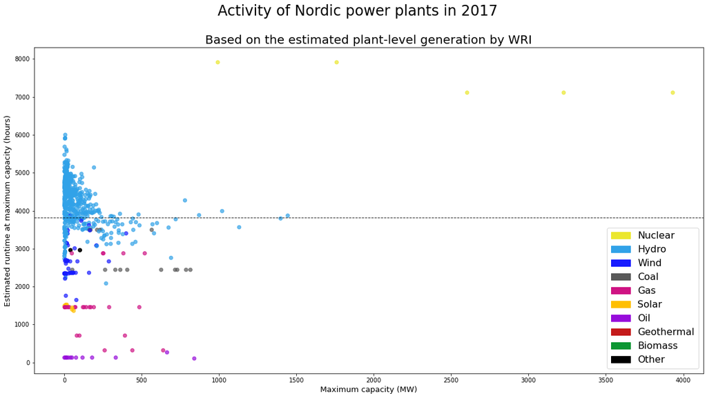

```python
from matplotlib.patches import Patch

plt.figure(figsize=[20,10])

plt.scatter(estimated_runtime_Nordic['capacity_mw'], estimated_runtime_Nordic['estimated_running_hours_2017'],
           c=estimated_runtime_Nordic['primary_fuel'].map(colors), alpha=0.7)
plt.axhline(y=3812, linestyle='--', c='black', alpha=0.8, linewidth=1) # mean of y values (calculated previously)

legend_elems = []
for fuel in colors:
    legend_elems.append(Patch(color=colors[fuel], label=fuel))

plt.legend(handles=legend_elems, prop={'size':16})
plt.suptitle('Activity of Nordic power plants in 2017', fontsize=24)
plt.title('Based on the estimated plant-level generation by WRI', fontsize=20)
plt.xlabel('Maximum capacity (MW)', fontsize=13)
plt.ylabel('Estimated runtime at maximum capacity (hours)', fontsize=13)

plt.show()
```

```python
estimated_runtime_Nordic.corrwith(estimated_runtime_Nordic['estimated_running_hours_2017'])['capacity_mw']
```

```
0.07031979451162944
```

Analysis results:

- Correlation between running hours and capacity seems to be nonexistent across all fuel types (confirmed by the correlation calculation above)
- In most cases, running hours seem to correlate with the fuel type (in the chart the points of same color often fall on the same horizontal line). However, we have to remember that the data used for this plot is generated by a machine learning model, which might compensate the missing energy generation data by assuming the aforementioned correlation. I wouldn't draw strong conclusions based on this observation.

For comparison, I will draw the same plot using the actual published generation data.

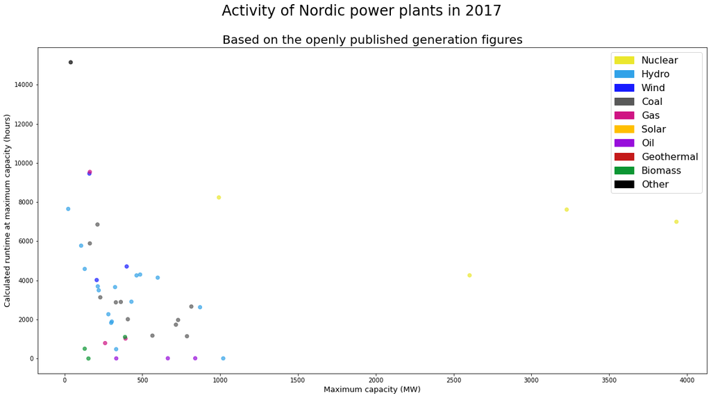

```python
plt.figure(figsize=[20,10])

plt.scatter(estimated_runtime_Nordic['capacity_mw'], estimated_runtime_Nordic['running_hours_2017'],
           c=estimated_runtime_Nordic['primary_fuel'].map(colors), alpha=0.7)

legend_elems = []
for fuel in colors:
    legend_elems.append(Patch(color=colors[fuel], label=fuel))

plt.legend(handles=legend_elems, prop={'size':16})
plt.suptitle('Activity of Nordic power plants in 2017', fontsize=24)
plt.title('Based on the openly published generation figures', fontsize=20)
plt.xlabel('Maximum capacity (MW)', fontsize=13)
plt.ylabel('Calculated runtime at maximum capacity (hours)', fontsize=13)

plt.show()
```

The points seem to lie more scattered but the lack of data makes it difficult to see the trend well. Also, there are definitely inconsistencies with the data since the calculated runtimes in some cases exceed the number of hours in a year (8760).